# MASZ - Projekt 9 Błądzenia losowe

Ryszard Szymański

5/16/2020

# Zadanie 1,2,3,4

Obliczenia dotyczące wartości gęstości ergodycznej przeprowadzono na wygenerowanym grafie BA o 90 wierzchołkach, gdzie podczas każdej iteracji dodawane były 3 krawędzie.

```r
ba_graph <- barabasi.game(90, m = 3, directed = FALSE)
ba_graph_adjacency_matrix <- get.adjacency(ba_graph)
transition_matrix <- t(ba_graph_adjacency_matrix) / degree(ba_graph)
```

```r
simulate_ergodicity <- function(transition_matrix) {
  current_matrix <- transition_matrix
  repeat{
    prev_matrix <- current_matrix
    current_matrix <- transition_matrix %*% current_matrix
    if (norm(current_matrix - prev_matrix) < 1e-9) {
      break
    }
  }

  current_matrix
}

dynamic_version_result <- simulate_ergodicity(transition_matrix)
```

Następnie w celu weryfikacji skorzystano z metody numerycznej i wyznaczono wektor własny macierzy przejść. Należy pamiętać, że wbudowane funkcje mogą dokonywać dodatkowych operacji przy obliczaniu wartości własnych.

```r
ev <- eigen(t(transition_matrix))
steady_state_vector <- ev$vectors[, 1] / sum(ev$vectors[, 1])
```

Ponieważ uzyskane wartości numeryczne są nieczytelne, porównano wyniki obu metod na wykresie. Wyniki zestawiono z wartościami stopni wierzchołków.

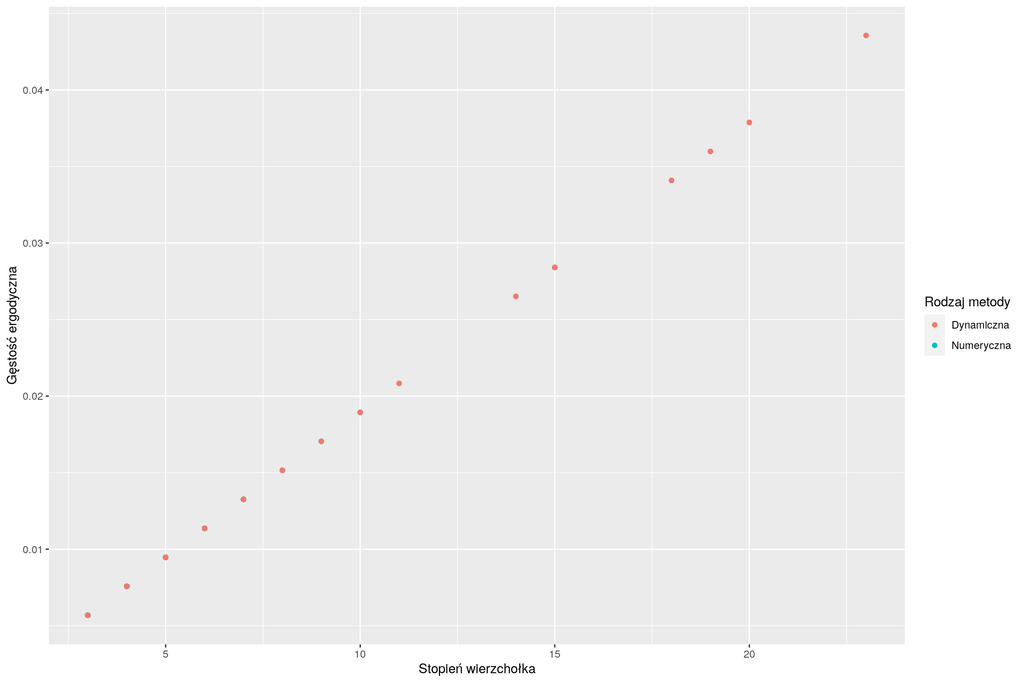

```r
df_results <- data.frame(
  degree = degree(ba_graph),
  numerical_method = steady_state_vector,
  dynamic_method = dynamic_version_result[1, ]
)

df_results %>%
  pivot_longer(2:3, names_to = "method", values_to = "value") %>%
  mutate(method = ifelse(method == "dynamic_method", "Dynamiczna", "Numeryczna")) %>%
  ggplot(aes(x = degree, y = value, color = method)) +
  geom_point() +
  guides(color = guide_legend(title = "Rodzaj metody")) +
  labs(x = "Stopień wierzchołka", y = "Gęstość ergodyczna")
```

Można zauważyć liniową zależność między gęstością ergodyczną a stopniem wierzchołka, co jest zgodne ze wskazówką z wykładu, że zalezność można zapisać jako $\pi_i = C \cdot k_i$. Wartość stałej można wyznaczyć za pomocą regresji liniowej:

```r
fitted_lm <- lm(numerical_method ~ degree + 0, df_results)
fitted_lm$coefficients %>%
  knitr::kable(format = "html", col.names = "Wartość stałej") %>%
  kableExtra::kable_styling(full_width = FALSE, position = "center")
```

|  | Wartość stałej |
| --- | --- |
| degree | 0.0018939 |

## Zadanie 5 i 6

Zaimplementowano własną wersję algorytmu PageRank z użyciem metody numerycznej (wyznaczenie wartości własnej). Jej wynik porównano z wynikiem implementacji dostępnej w pakiecie `igraph`

```r
test_graph <- ba.game(10, directed = FALSE)
my_pagerank <- function(graph, damping_factor = 0.85) {
  N <- vcount(graph)
  adjacency_matrix <- get.adjacency(graph)
  transition_matrix <- t(adjacency_matrix / degree(graph))

  R <- ones(nrow(transition_matrix)) / N
  page_rank_transition_matrix <- damping_factor * transition_matrix + (1 - damping_factor) * R
  ev <- eigen(page_rank_transition_matrix)

  ev$vectors[, 1] / sum(ev$vectors[, 1])
}
```

| Własna implementacja | Wbudowana funkcja w pakiecie igraph |
| --- | --- |
| 0.1101568 | 0.1101568 |
| 0.2005302 | 0.2005302 |
| 0.1060711 | 0.1060711 |
| 0.1140199 | 0.1140199 |
| 0.0634585 | 0.0634585 |
| 0.1101568 | 0.1101568 |
| 0.0618166 | 0.0618166 |
| 0.1101568 | 0.1101568 |
| 0.0618166 | 0.0618166 |
| 0.0618166 | 0.0618166 |

# Projekt

Do rozwiązania problemu zastosowano symulowane wyżarzanie, gdzie początkowy graf wygenerowany zostaje za pomocą modelu $G_{NM}$. Następnie w trakcie kolejnych iteracji każda krawędź jest przepinana z określonym prawdopodobieństwem $p$. Korzystając z równoważności do problemu średniej drogi minimalizowana jest właśnie średnia droga grafu.

```r
find_best_diffusion_graph
```

```
## function (vertex_count, edges_count, rewire_prob, start_temperature = 300,
##     temperature_lowering_factor = 0.9, steps = 10)
## {
##     graph <- erdos.renyi.game(vertex_count, edges_count, type = "gnm")
##     start_graph <- graph
##     current_temperature <- start_temperature
##     stopifnot(temperature_lowering_factor < 1 && temperature_lowering_factor >
##         0)
##     boltzman_constant <- 1.380649 * 1e-23
##     energies <- c()
##     for (step in seq_len(steps)) {
##         start_energy <- igraph::mean_distance(graph, unconnected = FALSE)
##         changed_graph <- rewire(graph, each_edge(prob = rewire_prob))
##         new_energy <- igraph::mean_distance(changed_graph, unconnected = FALSE)
##         energy_change <- new_energy - start_energy
##         is_change_beneficial <- energy_change < 0
##         current_temperature <- temperature_lowering_factor *
##             current_temperature
##         acceptance_ratio <- exp(-energy_change/(boltzman_constant *
##             current_temperature))
##         accept_bad_change <- runif(1) < acceptance_ratio
##         if (is_change_beneficial || accept_bad_change) {
##             graph <- changed_graph
##             energies <- c(energies, new_energy)
##         }
##         else {
##             energies <- c(energies, start_energy)
##         }
##     }
##     list(start_graph = start_graph, end_graph = graph, energies = energies)
## }
```

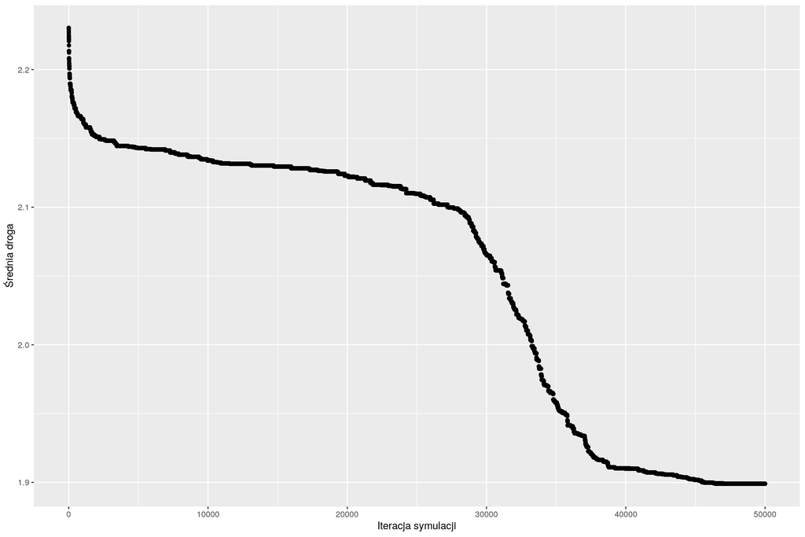

```r
simulation_results <- drake::readd(best_diffusion_graph_result)

qplot(x = seq_along(simulation_results$energies) , y = simulation_results$energies) +
  labs(x = "Iteracja symulacji", y = "Średnia droga")
```

Poniżej przedstawiono graf poczatkowy oraz graf wynikowy:

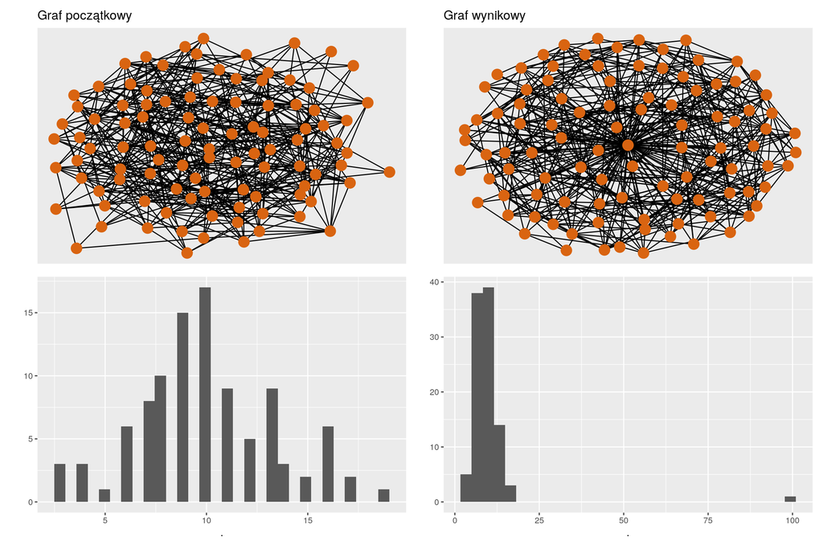